# hw03

Prerna Gupta

```r
library(gapminder)
library(dplyr)
```

```r
library(ggplot2)
library(tidyr)
```

# Task 1 : Report the absolute and/or relative abundance of countries with low life expectancy over time by continent.

First, I will use summarise to calculate mean and median life expectancy.

```r
gapminder %>%
  summarise(mean(lifeExp), median(lifeExp))
```

```
## # A tibble: 1 x 2
##   `mean(lifeExp)` `median(lifeExp)`
##             <dbl>             <dbl>
## 1            59.5              60.7
```

Since there is not much difference between the mean and the median. I will use the mean value. And calculate the number of countries in each continent

```r
gapminder %>%
  group_by(continent, year)%>%
  mutate(total_countries = length(unique(country)))%>%
  filter(lifeExp < 59.47444)%>%
  group_by(continent, year)%>%
  mutate(no_of_countries = length(unique(country)))%>%
  mutate(percentage_of_countries= (no_of_countries/total_countries)*100)%>%
  select(continent, year, no_of_countries, total_countries, percentage_of_countries) %>%
  arrange(continent) %>%
  as_tibble( )
```

```
## # A tibble: 809 x 5
##    continent  year no_of_countries total_countries percentage_of_countries
##    <fct>     <int>           <int>           <int>                   <dbl>
##  1 Africa     1952              52              52                   100
##  2 Africa     1957              52              52                   100
##  3 Africa     1962              51              52                    98.1
##  4 Africa     1967              50              52                    96.2
##  5 Africa     1972              50              52                    96.2
##  6 Africa     1977              49              52                    94.2
##  7 Africa     1952              52              52                   100
##  8 Africa     1957              52              52                   100
##  9 Africa     1962              51              52                    98.1
## 10 Africa     1967              50              52                    96.2
## # … with 799 more rows
```

This gives us 809 rows of data and is very time consuming to go over each row to see the absolute and relative abundance of countriies with low life Expectancy over time by continent. So we can make this data presentable through two graphs. However, due to the usage of arrange function we can easily observe that Oceania’s life expectancy has been reported as above the mean life expectancy from 1952 to 2007.

# Graph for absolute number of countries with low life expectancy over time by continent

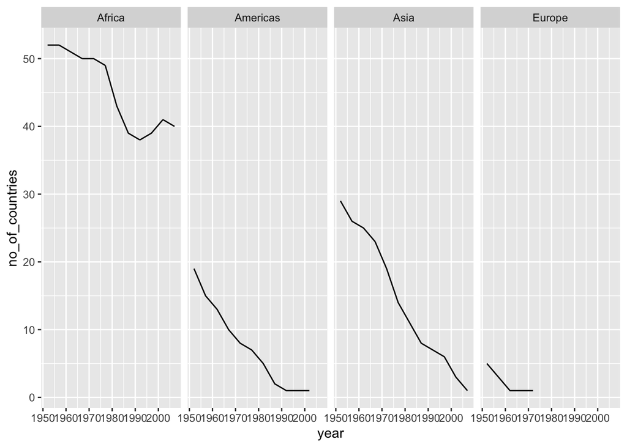

```r
gapminder %>%
  group_by(continent, year)%>%
  mutate(total_countries = length(unique(country)))%>%
  filter(lifeExp < 59.47444)%>%
  group_by(continent, year)%>%
  mutate(no_of_countries = length(unique(country)))%>%
  mutate(percentage_of_countries= (no_of_countries/total_countries)*100)%>%
  select(continent, year, no_of_countries, lifeExp, percentage_of_countries) %>%
  ggplot(aes(year,no_of_countries), color = continent) +
  geom_line() +
  facet_wrap(~continent, nrow = 1)
```

This graph adequately summarizes the table above and shows that the number of countries with low life expectancy are declining in each continent. However, we are unable to accurately understand how different continents are doing relative to each.

# Graph for relative number of countries with low life expectancy over time by continent

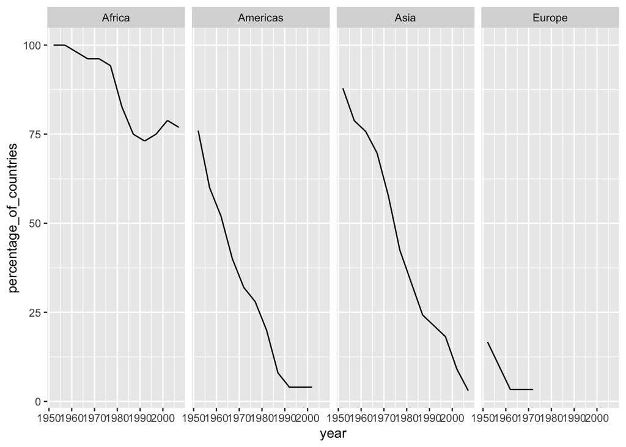

```r
gapminder %>%
  group_by(continent, year)%>%
  mutate(total_countries = length(unique(country)))%>%
  filter(lifeExp < 59.47444)%>%
  group_by(continent, year)%>%
  mutate(no_of_countries = length(unique(country)))%>%
  mutate(percentage_of_countries= (no_of_countries/total_countries)*100)%>%
  select(continent, year, no_of_countries, lifeExp, percentage_of_countries) %>%
  ggplot(aes(year,percentage_of_countries), color = continent) +
  geom_line() +
  facet_wrap(~continent, nrow = 1)
```

This graph helps us better grasp how the life expectancy has been improving in each continent over time. We can observe that while the number of countries with low life expectancy have decreased steeply in the Americas, Asia and Europe, the countries in Africa have not experienced such an improvement. This is a rather worrying observation.

# Task 2: Get the maximum and minimum of GDP per capita for all continents.

```r
extremeGDP <- gapminder %>%
              group_by(continent) %>%
              summarize(min_GDP = min(gdpPercap),
                        max_GDP = max(gdpPercap)) %>%
              as_tibble()
extremeGDP %>%
            knitr::kable()
```

| continent | min_GDP | max_GDP |
| --- | --- | --- |
| Africa | 241.1659 | 21951.21 |
| Americas | 1201.6372 | 42951.65 |
| Asia | 331.0000 | 113523.13 |
| Europe | 973.5332 | 49357.19 |
| Oceania | 10039.5956 | 34435.37 |

I was facing dificulties with plotting these so I took help from [Harper Cheng’s hw](https://stat545-ubc-hw-2019-20.github.io/stat545-hw-harpercheng91/hw03/A3.html) which was very easy for me to understand. I realised that this can be done with pivoting too that we learnt in class only today. So I stuck with the gather function.

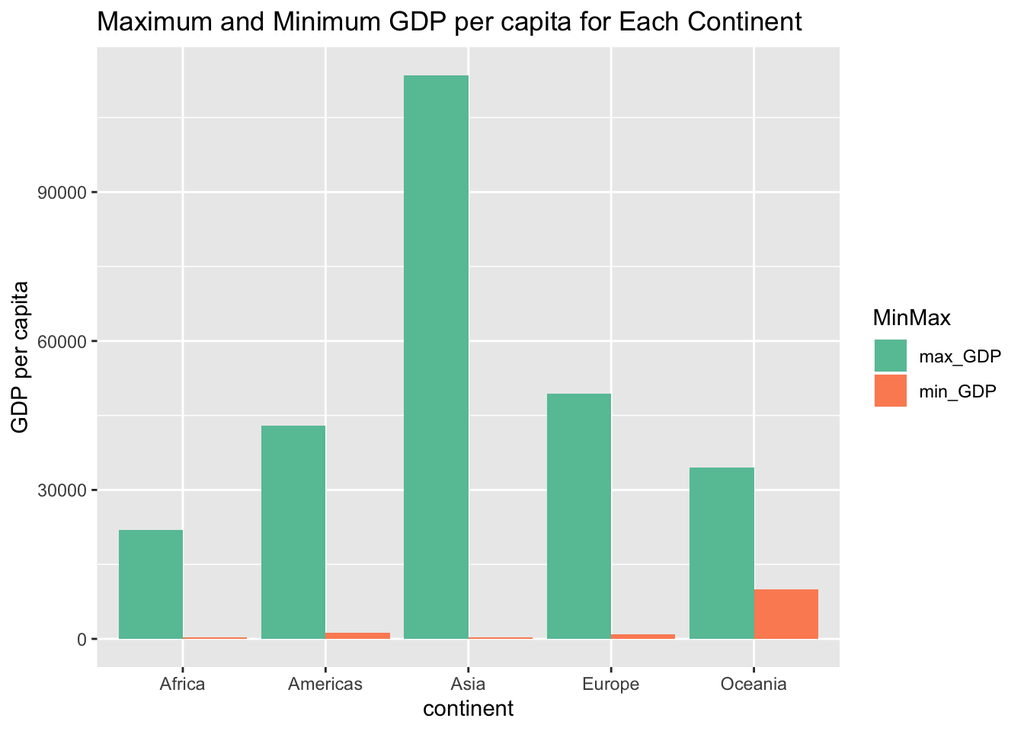

```r
dat <- extremeGDP %>%
  gather(MinMax, gdp, c(min_GDP, max_GDP))

ggplot(dat, aes(x=continent, y=gdp, fill=MinMax)) +
   geom_col(position = "dodge") +
   labs(title='Maximum and Minimum GDP per capita for Each Continent',
          y='GDP per capita')+
   scale_fill_brewer(palette="Set2")
```

# Task 6: Finding countries with interesting stories

I wanted to find countries that have experience a dramatic drop in their lifeExpectancy since their first recorded life Expectancy in 1952. Such a drop would reveal countries that have not been doing so well and might help us investigate the reasons as well.

```r
gapminder %>%
  select(country, continent, year, lifeExp, gdpPercap) %>%
  group_by(country)%>%
  filter(lifeExp == first(lifeExp) | lifeExp == min(lifeExp)) %>%
  mutate(freq = n()) %>%
  ungroup() %>%
  filter(freq > 2 | freq == 2)
```

```
## # A tibble: 12 x 6
##    country   continent  year lifeExp gdpPercap  freq
##    <fct>     <fct>     <int>   <dbl>     <dbl> <int>
##  1 Botswana  Africa     1952    47.6      851.     2
##  2 Botswana  Africa     2002    46.6    11004.     2
##  3 Cambodia  Asia       1952    39.4      368.     2
##  4 Cambodia  Asia       1977    31.2      525.     2
##  5 Rwanda    Africa     1952    40        493.     2
##  6 Rwanda    Africa     1992    23.6      737.     2
##  7 Swaziland Africa     1952    41.4     1148.     2
##  8 Swaziland Africa     2007    39.6     4513.     2
##  9 Zambia    Africa     1952    42.0     1147.     2
## 10 Zambia    Africa     2002    39.2     1072.     2
## 11 Zimbabwe  Africa     1952    48.5      407.     2
## 12 Zimbabwe  Africa     2002    40.0      672.     2
```

From this table we find that Botswana in 2002, Cambodia in 1977, Rwanda in 1992, Swaziland in 2007, Zambia in 2002 and Zimbabwe in 2002 have experienced such an extreme low in thier lifeExpectancy. Five of the six such countries lie in Africa.

Let us now look at the median and mean of lifeExpectancy worldwide by year.

```r
gapminder %>%
  group_by(year)%>%
  summarise(mean_lifeExp = mean(lifeExp),
            median_lifeExp = median(lifeExp)) %>%
  mutate(change = (mean_lifeExp - lag(mean_lifeExp)) / lag(mean_lifeExp) * 100)
```

```
## # A tibble: 12 x 4
##     year mean_lifeExp median_lifeExp change
##    <int>        <dbl>          <dbl>  <dbl>
##  1  1952         49.1           45.1  NA
##  2  1957         51.5           48.4   4.99
##  3  1962         53.6           50.9   4.08
##  4  1967         55.7           53.8   3.86
##  5  1972         57.6           56.5   3.54
##  6  1977         59.6           59.7   3.34
##  7  1982         61.5           62.4   3.30
##  8  1987         63.2           65.8   2.73
##  9  1992         64.2           67.7   1.50
## 10  1997         65.0           69.4   1.33
## 11  2002         65.7           70.8   1.05
## 12  2007         67.0           71.9   2.00
```

Calculating the slope or the average rate of change of mean worldwide, so that we get a better idea of the rate at which life expectancy has been improving over a period of time.

```r
gapminder %>%
  group_by(year) %>%
  summarise(mean_lifeExp = mean(lifeExp),
            median_lifeExp = median(lifeExp)) %>%
  mutate(change = (mean_lifeExp - lag(mean_lifeExp)) / lag(mean_lifeExp) * 100) %>%
  drop_na() %>%
  ungroup() %>%
  summarise(average_rate_of_change = mean(change))
```

```
## # A tibble: 1 x 1
##   average_rate_of_change
##                    <dbl>
## 1                   2.88
```

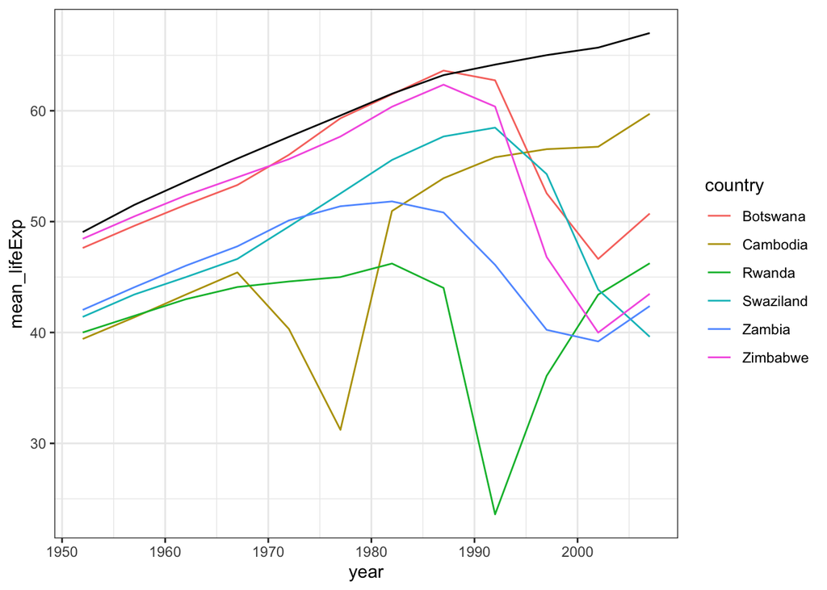

```r
gapminder %>%
  filter(country %in% c("Botswana", "Cambodia", "Rwanda", "Swaziland", "Zambia", "Zimbabwe")) %>%
  group_by(country, year) %>%
  summarise(mean_lifeExp = mean(lifeExp)) %>%
  ggplot() +
  geom_line(aes(year, mean_lifeExp, group = country, colour = country)) +
  geom_line(data = gapminder_meanlifeExp, aes(x = year, y = mean_lifeExp)) +
  theme_bw()
```